# STA 141C HW 1

Ishita Dutta

```r
library(tidyverse)
```

```r
library(ggplot2)
library(MASS)
library(mvtnorm)
```

# 1

```r
mat_vals = c(17, 3, 9, 4, 25, 21, 14, 22, 35)
mat1 <- matrix(mat_vals,nrow=3,ncol=3,byrow=TRUE)
mat1
```

```
##      [,1] [,2] [,3]
## [1,]   17    3    9
## [2,]    4   25   21
## [3,]   14   22   35
```

```r
mat_upper = mat1
mat_upper[mat_upper%%2==0] <- 0 #elements not divisible by 2 are replaced with 0 --> Upper matrix
mat_upper
```

```
##      [,1] [,2] [,3]
## [1,]   17    3    9
## [2,]    0   25   21
## [3,]    0    0   35
```

```r
mat_lower = mat1
mat_lower[mat_lower%%3==0] <- 0 #elements not divisible by 3 are replaced with 0 --> Lower matrix
mat_lower
```

```
##      [,1] [,2] [,3]
## [1,]   17    0    0
## [2,]    4   25    0
## [3,]   14   22   35
```

```r
mat_upper * mat_upper # Since we are squaring the matrix, we are multiplying 2
```

```
##      [,1] [,2] [,3]
## [1,]  289    9   81
## [2,]    0  625  441
## [3,]    0    0 1225
```

```r
# upper triangle matrices together.
```

This is also an upper triangle matrix.

```r
solve(mat_lower) # solve() is the R function to find the inverse of a matrix.
```

```
##              [,1]        [,2]       [,3]
## [1,]  0.058823529  0.00000000 0.00000000
## [2,] -0.009411765  0.04000000 0.00000000
## [3,] -0.017613445 -0.02514286 0.02857143
```

This is also a lower triangle matrix.

```r
matvals = c(1, 3, 9, 4, 1, 21, 14, 22, 1)
mat2 <- matrix(matvals,nrow=3,ncol=3,byrow=TRUE)
mat_upper_2 = mat2
mat_upper_2[mat_upper_2%%2==0] <- 0 #elements not divisible by 2 are replaced with 0 --> Upper matrix
mat_lower_2 = mat2
mat_lower_2[mat_lower_2%%3==0] <- 0 #elements not divisible by 3 are replaced with 0 --> Lower matrix
mat_lower_2 * mat_lower_2
```

```
##      [,1] [,2] [,3]
## [1,]    1    0    0
## [2,]   16    1    0
## [3,]  196  484    1
```

Also a unit lower triangle matrix.

```r
solve(mat_upper_2)
```

```
##      [,1] [,2] [,3]
## [1,]    1   -3   54
## [2,]    0    1  -21
## [3,]    0    0    1
```

Also unit upper triangle.

# 2

```r
# givens
a = 0.7
b = 0.2
c = 0.1

#operations
cat("a =",a, "b =", b, "c =", c)
```

```
## a = 0.7 b = 0.2 c = 0.1
```

```r
cat("\n(a + b) + c =", (a + b) + c)
```

```
##
## (a + b) + c = 1
```

```r
cat("\na + (b + c) =", a + (b + c))
```

```
##
## a + (b + c) = 1
```

```r
cat("\n(a + c) + b =", (a + c) + b)
```

```
##
## (a + c) + b = 1
```

They all print 1. Associative property holds true because no matter which two numbers are being added first, the total of all three numbers is the same = 1.

# 3

```r
# set sequence
x = seq(0.988,1.012,0.001)
# y1 --> expanded, y2 --> not expanded
y1 = (x ** 7) - 7*(x ** 6) + 21*(x ** 5) - 35*(x ** 4) + 35*(x ** 3) - 21*(x ** 2) + 7*(x) - 1
y2 = (x - 1) ** 7
#showing points y1 and y2
data.frame(x, y1, y2)
```

```
##        x            y1            y2
## 1  0.988 -3.552714e-14 -3.583181e-14
## 2  0.989 -2.309264e-14 -1.948717e-14
## 3  0.990 -1.421085e-14 -1.000000e-14
## 4  0.991 -7.993606e-15 -4.782969e-15
## 5  0.992  8.881784e-16 -2.097152e-15
## 6  0.993  2.664535e-15 -8.235430e-16
## 7  0.994 -1.776357e-15 -2.799360e-16
## 8  0.995 -3.552714e-15 -7.812500e-17
## 9  0.996 -1.776357e-15 -1.638400e-17
## 10 0.997 -2.664535e-15 -2.187000e-18
## 11 0.998 -8.881784e-16 -1.280000e-19
## 12 0.999 -1.776357e-15 -1.000000e-21
## 13 1.000  0.000000e+00  0.000000e+00
## 14 1.001  8.881784e-15  1.000000e-21
## 15 1.002 -6.217249e-15  1.280000e-19
## 16 1.003  1.776357e-15  2.187000e-18
## 17 1.004 -1.776357e-15  1.638400e-17
## 18 1.005 -8.881784e-16  7.812500e-17
## 19 1.006  5.329071e-15  2.799360e-16
## 20 1.007  7.105427e-15  8.235430e-16
## 21 1.008 -4.440892e-15  2.097152e-15
## 22 1.009 -3.552714e-15  4.782969e-15
## 23 1.010  1.421085e-14  1.000000e-14
## 24 1.011  1.154632e-14  1.948717e-14
## 25 1.012  4.618528e-14  3.583181e-14
```

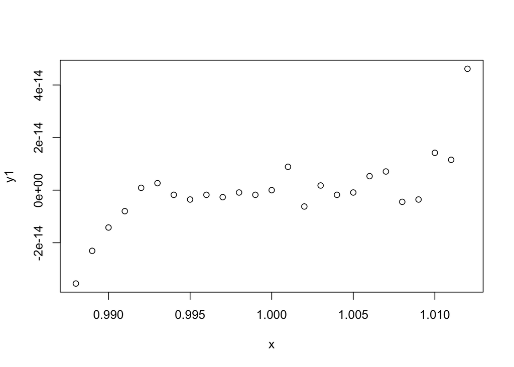

```r
#plot the two graphs
plot(x, y1)
```

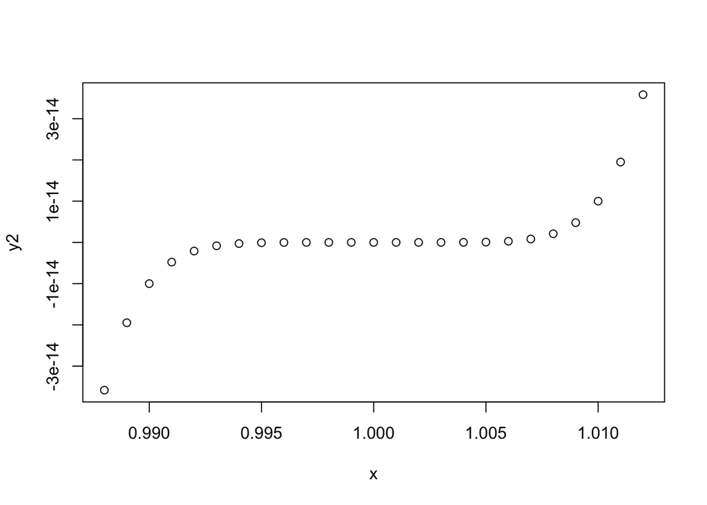

```r
plot(x, y2)
```

Values are slightly different at certain points. The expanded polynomial graph is less coherent than the non-expanded(?) polynomial graph. Could be something to do with the rounding in either of the two equations. This is because we are calculating each of the terms separately in the expanded model because we are rounding each term before adding it. In the case of the non-expanded model, we are rounding after the entire calculation or at the end, so there is a higher chance of a streamlined/coherent graph to what a x^7 plot would look like.

# 4

```r
# get data
datvals = read.table('oringp.dat')
# rename columns to accurate values
colnames(datvals) = c('flight number', 'date', 'number of O-rings', 'number failed', 'temperature at launch')
head(datvals)
```

```
##   flight number     date number of O-rings number failed temperature at launch
## 1             1  4/12/81                 6             0                    66
## 2             2 11/12/81                 6             1                    70
## 3             3  3/22/82                 6             0                    69
## 4             5 11/11/82                 6             0                    68
## 5             6  4/04/83                 6             0                    67
## 6             7  6/18/83                 6             0                    72
```

```r
cor(datvals[1:length(datvals$date) - 1, c('number failed', 'temperature at launch')]) # correlation coefficients
```

```
##                       number failed temperature at launch
## number failed             1.0000000            -0.5613284
## temperature at launch    -0.5613284             1.0000000
```

The correlation for temperature and number of failures for all the launches except for the disaster is -0.5613284.

# 5

## a

```r
# set givens
set.seed(020222)
s0 = 1
s1 = 2
n = 100
q = 5

#calculate needed values
mu = sample(seq(0, 10), size = 100, replace = TRUE)
Z = matrix(sample(seq(0, 5), size = c(500), replace = TRUE), ncol = 5, byrow = TRUE)
I = diag(100)
cov = (s1**2)*(Z %*% t(Z)) + (s0**2)*I
data.frame(cov[c(1:5), c(1:5)])
```

```
##    X1  X2  X3  X4 X5
## 1 137 112  44  60 84
## 2 112 241 120 156 76
## 3  44 120 121  96 48
## 4  60 156  96 113 56
## 5  84  76  48  56 85
```

```r
dim(cov)
```

```
## [1] 100 100
```

```r
#get regression
Y = mvrnorm(mu = mu, Sigma =  cov)
length(Y)
```

```
## [1] 100
```

## b

```r
# log likelihood
dmvnorm(Y, mu, cov, log=TRUE)
```

```
## [1] -178.3961
```

## c

```r
n <- 100
q <- 5
sigma0 <- 1
sigma1 <- 2
mu <- rnorm(n)
Z <- matrix(rnorm(n*q), nrow=n)
cross_Z = Z %*% t(Z)

Sigma <- sigma1^2 * cross_Z + sigma0^2 * diag(n)
y <- rmvnorm(n, mu, Sigma)
log_dmvnorm <- dmvnorm(y, mean = mu, sigma = Sigma, log = TRUE)

# evaluate log-density using Woodbury formula and matrix determinant lemma
Iq <- diag(q)
V <- Z %*% solve(Iq + sigma1^-2 * t(Z) %*% Z)
U <- sigma1^-2 * Z
Ainv <- solve(sigma0^2 * diag(n))  # inverse of (σ0^2 * I_n)
log_dmvnorm_lowrank <- -log(2*pi)*n/2 - log(sigma0^2)*n/2 - log(det(Iq + sigma1^-2 * t(Z) %*% Z))/2 - (y - mu) %*% (Ainv - Ainv %*% U %*% solve(Iq + t(V) %*% Ainv%*% U) %*% t(U) %*% Ainv) %*% (y - mu)/(2 * sigma0^2)
```

## d

```r
# d
dmvnorm_lowrank <- function(y, mu, Z, sigma0, sigma1, log = FALSE){
  n <- length(y)
  q <- ncol(Z)
  A <- sigma0^2 * diag(n)
  U <- Z
  V <- t(Z)
  Im <- diag(n)

  Sigma_inv <- solve(A) - solve(A) %*% U %*% solve(Im + V %*% solve(A) %*% U) %*% t(U) %*% solve(A)
  log_det_Sigma <- sum(log(diag(Im + V %*% solve(A) %*% U))) + n*log(sigma0^2)

  log_dmvnorm_lowrank <- -n/2*log(2*pi) - 1/2*log_det_Sigma - 1/2*t(y-mu) %*% Sigma_inv %*% (y-mu)

  if(log){
    return(log_dmvnorm_lowrank)
  }else{
    return(exp(log_dmvnorm_lowrank))
  }
}
```

## e

```r
# e
#log_dmvnorm_lowrank <- dmvnorm_lowrank(y, mu, Z, sigma0, sigma1, log = TRUE)
```